# Advanced Statistical Analysis of Fitness Data for Predictive Insights & Personalization

Research Project (SMST604)

Purva Amit Puranik(3032411004)

DES Pune University — Dept. of Statistics

Omkar Nilesh Ninav(3532411003)

DES Pune University — Dept. of Statistics

2025-11-12

## Motivation Behind the Project

- **Fitness data** reflecting exercise patterns, body composition, and lifestyle factors offer valuable opportunities for **quantitative analysis**.
- Understanding how these factors **interact** can help reveal **key determinants of progress** and explain **variations in individual performance**.
- The project focuses on building **statistical and predictive models** to detect **performance plateaus** and **forecast outcomes** for fitness improvement.
- Metrics such as the **Resilience Index** and **Progress Ratio** aim to make analytics more **interpretable and actionable** for individual users.

## Proposed Research Questions

1. To what extent does **consistent workout completion** lead to a **significant improvement in body fat percentage**, e.g., meeting weekly or monthly targets?
2. Can a **Bayesian Structural Time Series (BSTS)** model accurately **forecast stagnation** in key physiological metrics (e.g., body fat %, BMI) at least **one week in advance**?
3. What distinct **client clusters** emerge from an **unsupervised analysis** of longitudinal activity and progress data (e.g., *Fast Responders*, *At-Risk Plateauers*)?
4. How can **Resilience Index** and **Progress Ratio** be **quantitatively defined and operationalized**, and do these metrics **correlate with long-term user success and engagement**?

# Technical Details and Domain Knowledge

## Interdisciplinary Scope

- Combines **statistics, exercise physiology, and wearable technology**.
- Uses **synthetically generated data** designed to reflect real-world exercise and lifestyle patterns.
- Bridges the gap between **data science and human performance understanding**.

## Personalization and Adaptation

- Applies **clustering** to identify groups with similar fitness responses.
- Uses **adaptive models** that update as new data are generated.
- Enables **personalized progress tracking** and interpretable metrics such as the *Resilience Index* and *Progress Ratio*.

# Statistical Methodologies

## General Analysis

- **Descriptive statistics** to summarize fitness metrics (e.g., mean, variance, correlation).
- **Inferential tests** to examine the impact of workout consistency on body fat %.
- **Regression modeling** to quantify relationships between input features and outcomes.

## Predictive Modeling

- **Bayesian Structural Time Series (BSTS)** to forecast stagnation in metrics like body fat % or BMI.
- Model validation through **posterior predictive checks** and **forecast accuracy measures** (e.g., MAE, RMSE).
- Helps in **early detection of plateaus** and **performance forecasting**.

## Unsupervised Learning

- **Clustering algorithms** (e.g., K-Means, Hierarchical, or DBSCAN) to segment users.
- Identify behavioral groups such as *Fast Responders* or *At-Risk Plateauers*.
- Use **Principal Component Analysis (PCA)** for dimensionality reduction and visualization.

## Custom Metrics and Correlation

- Define **Resilience Index** (recovery and adaptability measure) and **Progress Ratio** (rate of improvement).
- Validate these metrics using **correlation** and **regression analysis** against long-term success indicators.

# Proposed Analytical Pipeline & Flow

- The analytical workflow integrates **data preprocessing, sampling**, and **four core research questions (RQ1–RQ4)**.
- Covers **causal inference, time-series forecasting, clustering, and personalized metric modeling**.

## RQ1 – Causal Effect of Workout Consistency

- Estimate effect of **workout consistency** on **body fat %** using **Marginal Structural Models (MSM)**.
- Apply **Inverse Probability of Treatment Weighting (IPTW)** for bias adjustment.
- Validate robustness through **sensitivity and model diagnostics**.

## RQ2 – Plateau Forecasting

- Fit **Bayesian Structural Time Series (BSTS)** models to forecast stagnation in fat %.
- Evaluate forecast accuracy using **posterior probabilities**, **precision**, **recall**, and **calibration curves**.

## RQ3 – User Segmentation

- Perform **Principal Component Analysis (PCA)** for dimensionality reduction.
- Identify clusters using **K-Means** and **Bayesian Gaussian Mixture Models (BGMM)**.
- Validate cluster stability and interpret **behavioral–physiological profiles**.

## RQ4 – Personalized Metrics

- Compute **Progress Ratio** and **Resilience Index** from user trajectories.
- Assess associations using **OLS regression** and **Cox survival models**.
- Apply **SHAP values** for interpretability and insight into feature importance.

## Details About the Data

| **Category** | **Variables** | **Distribution** | **Statistical Justification** |
| --- | --- | --- | --- |
| Physical & Biometric | Height, Weight, Chest, Waist, Neck, BMI | Truncated Normal | Reflects natural variation; truncation ensures realistic physiological limits; preserves proportional relationships among traits |
| Behavioral & Categorical | Exercise Schedule, Consistency, Gender | Bernoulli / Categorical | Discrete behavioral variables; probabilities reflect empirical proportions |
| Exercise Performance | Sets, Reps, Weight Lifted | Log-Normal / Discrete Normal | Captures skewed exercise output; discrete normal for symmetric count data like reps |
| Temporal Progress | Weekly Weight, Body Fat %, Caloric Change | AR(1) / Logistic Decay | Models temporal autocorrelation and diminishing returns in physiological adaptation |
| Lifestyle | Sleep Hours, Calories Burned | Uniform / Normal | Captures wide individual variability without strong skew |

# Summary of Research Papers

## Piwek et al. (2016) — *The Rise of Consumer Health Wearables*

- Discusses the exponential growth of **wearable health technology** and its potential for personalized analytics.
- Highlights barriers like **data accuracy, non-adherence, and missingness**, motivating rigorous **statistical modeling of behavioral data**.
- Establishes the need for **predictive, interpretable models** beyond descriptive tracking.

## Fitzmaurice et al. (2011) — *Applied Longitudinal Analysis*

- Provides a rigorous framework for modeling **repeated measures** with correlated errors.
- Emphasizes **time-dependent confounding** and the limitations of standard regression approaches.
- Directly supports our **Marginal Structural Models (MSM)** and **Inverse Probability of Treatment Weighting (IPTW)** approach in RQ1.
- Ensures **causal validity** when estimating effects of workout consistency on body fat percentage.

## James et al. (2013) & Hastie et al. (2009) — *Statistical Learning Foundations*

- Together, these texts define the **statistical learning theory** guiding model design and validation.
- Provide a foundation for **regression, classification, clustering, PCA, and regularization**.
- Support **RQ3 (user segmentation)** through **dimensionality reduction (PCA)** and **Bayesian Gaussian Mixture Models (BGMM)**.
- Emphasize the **bias–variance tradeoff**, **cross-validation**, and **generalization performance** in predictive modeling.

## Klein & Moeschberger (2012) — *Survival Analysis: Techniques for Censored and Truncated Data*

- Formalizes methods for handling **censored and time-to-event data**.
- Supports modeling of **time-to-goal achievement** as a **survival process**.
- Enables linking **Resilience Index and Progress Ratio** with **probability of long-term success** using **Cox proportional hazards** models.
- Integrates traditional survival analysis with predictive modeling for personalized insight.

# Outputs & Interpretation (RQ1)

## Output of MSM (weighted least squares – Body fat%)

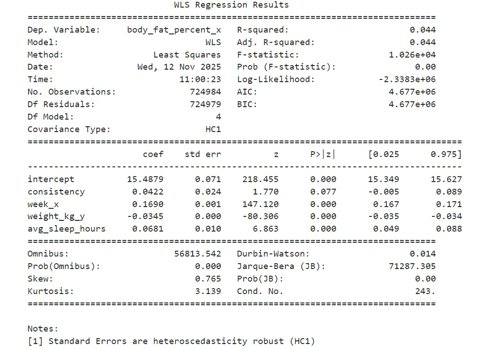

## Hypothesis and Interpretation

[output not shown]

## Overall Hypothesis

| Type | Null Hypothesis (H₀) | Alternative Hypothesis (H₁) | Decision |
| --- | --- | --- | --- |
| Model-level F-test | $H_0 : \beta_1 = \beta_2 = \beta_3 = \beta_4 = 0$ None of the predictors explain variation in fat%. | $H_1 : \text{At least one } \beta_i \neq 0.$ | F = 10,260, $p < 0.001 \to$ Reject $H_0$. Model is statistically significant. |

## Output of MSM (weighted least squares – BMI)

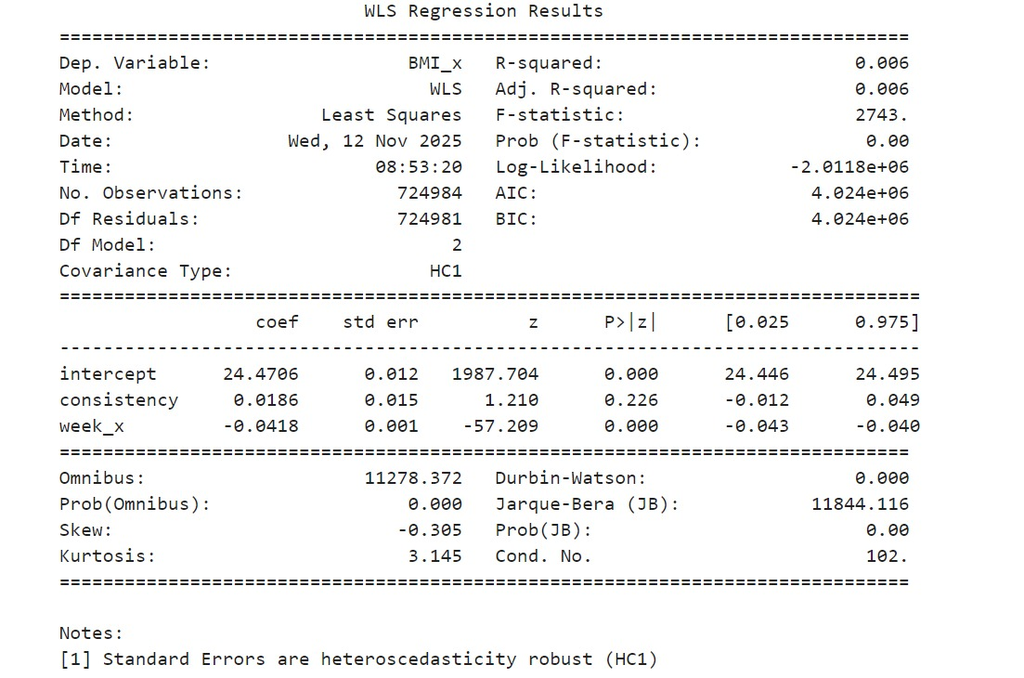

## Hypothesis and Interpretation

| Predictor | Null Hypothesis (H₀) | Alternative Hypothesis (H₁) | Decision | Coefficient (β) | P value | Interpretation |
| --- | --- | --- | --- | --- | --- | --- |
| Consistency | $\beta_1 = 0$ Consistency has no effect on BMI | $\beta_1 \neq 0$ Consistency has significant effect on BMI. | Accept H₀ | +0.0186 | 0.226 | Being consistent over a single week does not lead to a measurable short-term reduction in BMI |
| Week (Time) | $\beta_2 = 0$ Time has no effect on BMI | $\beta_2 \neq 0$ Time has a significant effect on BMI | Reject H₀ | -0.0418 | < 0.001 | Each additional week is associated with a −0.0418 unit decrease in BMI, suggesting a significant but gradual improvement trend over time |
| Intercept | $\beta_0 = 0$ No baseline BMI | $\beta_0 \neq 0$ Nonzero baseline BMI | Reject H₀ | 24.471 | < 0.001 | Baseline BMI is approximately 24.5kg/m² |

## **Rolling-Trend comparison plot** for **Smoothed Body Fat %** between consistent and inconsistent clients.

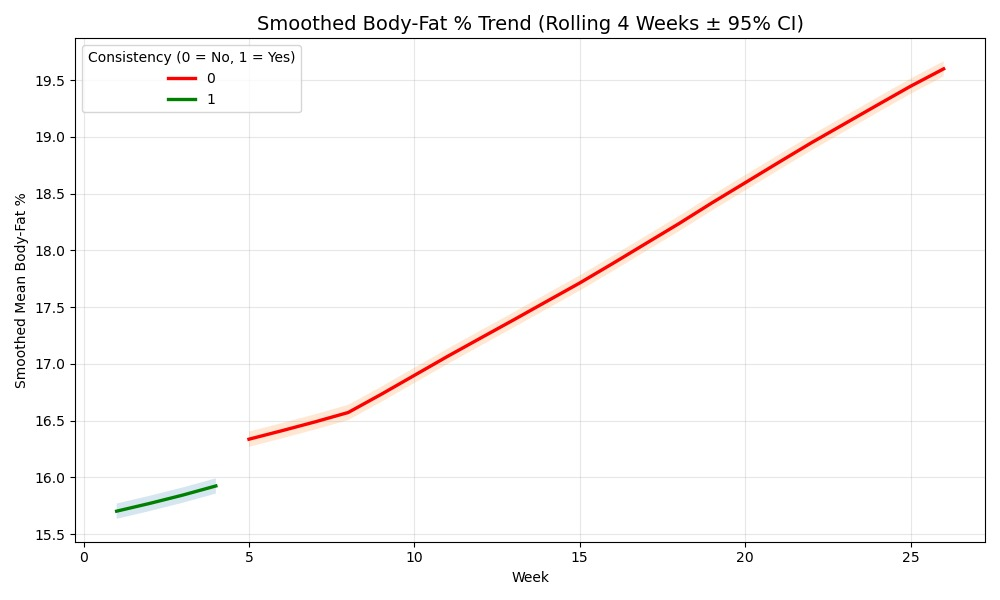

## Plateau Detection

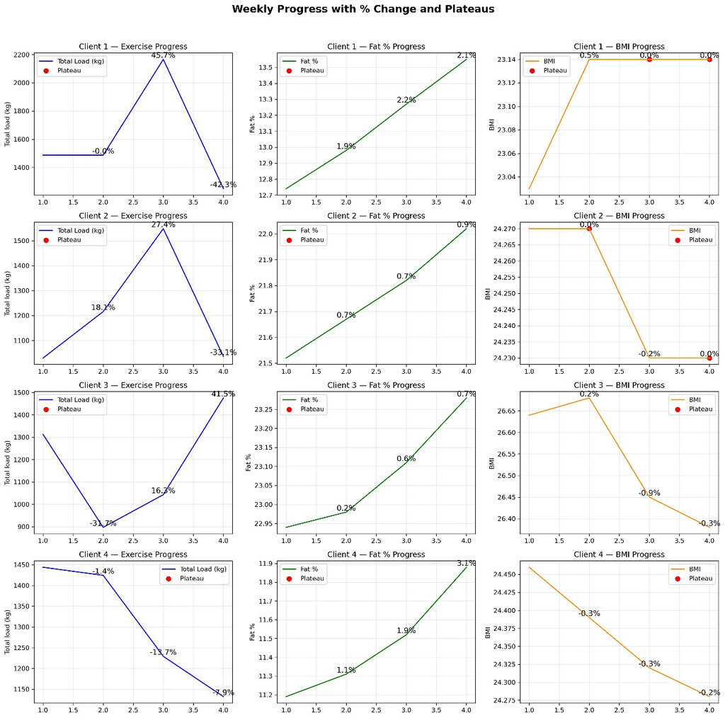

# User Segmentation Analysis

## Clustering Overview

- **Extended Analysis**: User segmentation via unsupervised learning
- **Dataset**: 80 users tracked over 26 weeks
- **Method**: K-Means clustering with 14 engineered features
- **Goal**: Identify distinct user groups for personalized interventions

## Feature Engineering for Clustering

Created **14 user-level features** across 4 categories:

- Static Features
- Behavioral Features
- Progress Features
- Strength Features
- Initial height, weight, BMI
- Initial body fat %
- Age, sex (dummy coded)
- Mean workout duration (min)
- Mean sleep hours
- **Resilience Index**: Mean days per week
- Weight change slope (overall)
- Body fat % change slope
- Plateau slopes (last 4 weeks)
- Bench press 1RM progression
- Calculated using Epley formula: `1RM = weight × (1 + reps/30)`

## Elbow Method for Optimal k

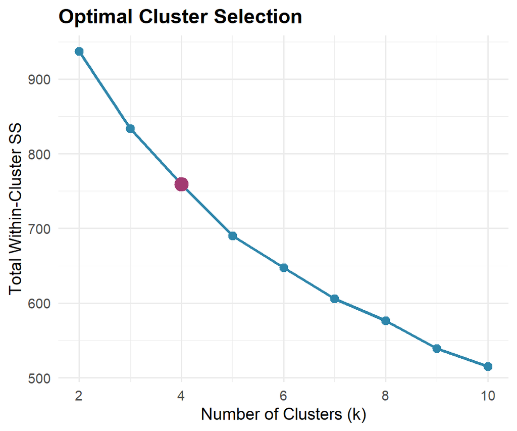

**Selected: k = 4**

## Cluster Visualization (PCA)

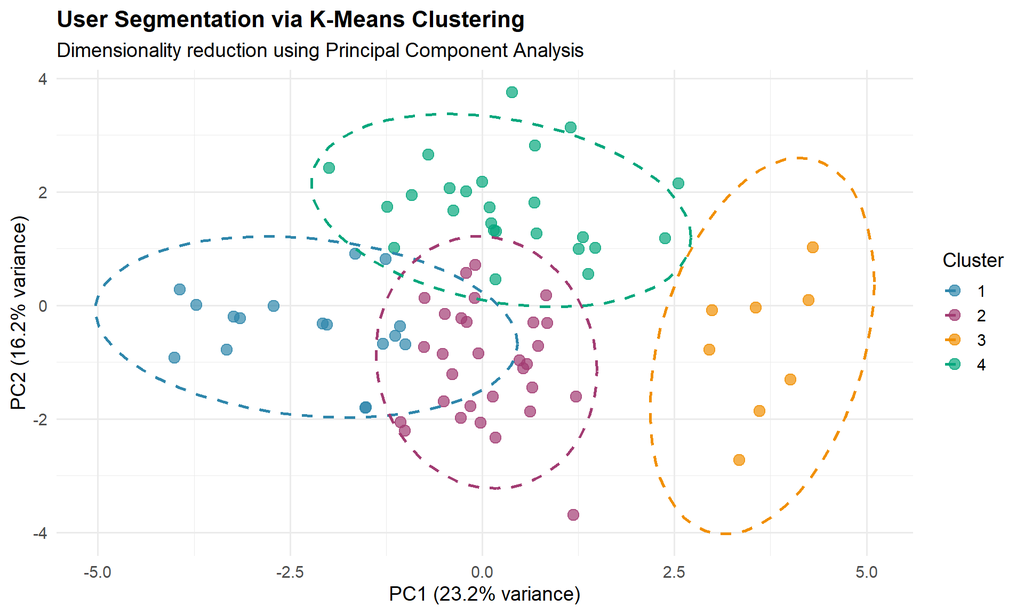

# Cluster Profiles

## Cluster 1: Young Male Athletes

**Demographics** (17 users)

- Age: 30.2 years
- 100% male
- Initial BMI: 25.2
- Initial Body fat: 11.4%

**Behavior**

- Workout Duration : 35.2 min/session
- Workout Frequency : 5.9 days/week
- Sleep Duration: 7 hrs

**Progress**

- Weight: ▼ 0.148 kg/week
- Body fat: ▲ 0.205%/week
- Strength: ▲ 0 kg/day

## Cluster 2: Middle-Aged Improvers

**Demographics** (30 users)

- Age: 39.3 years
- 100% male
- Initial BMI: 24.3
- Initial Body fat: 12.6%

**Behavior**

- Workout Duration : 35.5 min/session
- Workout Frequency : 4.7 days/week
- Sleep Duration: 6.7 hrs

**Progress**

- Weight: ▼ 0.115 kg/week
- Body fat: ▲ 0.142%/week
- Strength: ▲ 0.021 kg/day

**Profile**: Moderate fitness, consistent effort, balanced progress

## Cluster 3: Older Mixed Group

**Demographics** (8 users)

- Age: 49 years
- 38% male
- Initial BMI: 22.6
- Initial Body fat: 18%

**Behavior**

- Workout Duration : 33.9 min/session
- Workout Frequency : 3.3 days/week
- Sleep Duration: 6.3 hrs

**Progress**

- Weight: ▼ 0.065 kg/week
- Body fat: ▲ 0.084%/week
- Strength: ▲ 0.049 kg/day

**Profile**: Higher body fat, varied gender mix, slower progress

## Cluster 4: Younger Female Focus

**Demographics** (25 users)

- Age: 35.8 years
- 4% male
- Initial BMI: 24.8
- Initial Body fat: 21.4%

**Behavior**

- Workout Duration : 35.7 min/session
- Workout Frequency : 5.3 days/week
- Sleep Duration: 6.9 hrs

**Progress**

- Weight: ▼ 0.11 kg/week
- Body fat: ▲ 0.176%/week
- Strength: ▼ 0.007 kg/day

**Profile**: Younger demographic, high body fat, active lifestyle

# Personalized Metrics

## Framework Overview

Three key metrics for individualized tracking:

**Resilience Index**

Average workout days per week

*Measures behavioral consistency*

**Progress Ratio: Body Fat**

```
(initial - final) / initial
```

*% body composition improvement*

**Progress Ratio: Strength**

```
(final - initial) / initial
```

*% strength gains over time*

## Metrics by Cluster

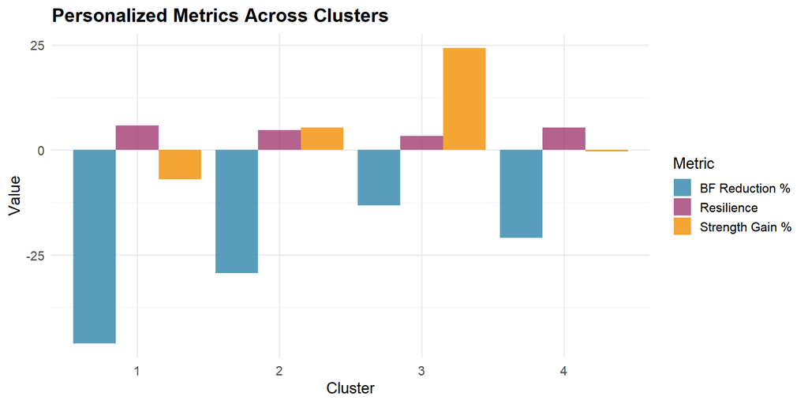

# Cluster-Based Recommendations

## Actionable Insights by Cluster

- Cluster 1
- Cluster 2
- Cluster 3
- Cluster 4

**Watch**: Sleep optimization (maintain 7+ hours)

**Recommendation**: Continue current program, consider periodization for sustained gains

**Strengths**: Moderate frequency, balanced approach

**Watch**: Possible plateau indicators in last 4 weeks

**Recommendation**: Increase training variation, focus on nutrition optimization

**Strengths**: Active participation despite age

**Recommendation**: Emphasize recovery protocols, adjust progressive overload

**Strengths**: High activity levels, good adherence

**Recommendation**: Comprehensive nutrition review, increase resistance training focus

## Implementation for Fitness Platforms

**Practical Applications:**

1. **Automatic Segmentation**: Classify new users based on intake assessments
2. **Personalized Dashboards**: Display cluster-specific metrics and benchmarks
3. **Targeted Interventions**: Deliver recommendations aligned with cluster profiles
4. **Comparative Analytics**: Enable users to compare progress against similar profiles

**Benefits:**

- Enhanced user engagement through personalization
- Data-driven coaching strategies
- Early identification of at-risk users
- Optimized resource allocation for interventions

## Future Directions

**Short-term Enhancements**

- Validate clusters with fitness domain experts
- A/B test cluster-based recommendations
- Extend analysis to additional exercise types
- Incorporate dietary data

**Long-term Research**

- Predictive modeling for individual outcomes
- Dynamic re-clustering as users evolve
- Integration with BSTS forecasting (RQ2)
- Survival analysis for long-term adherence

## Concluding Remarks

**Integrating Causal, Predictive, and Unsupervised Methods:**

**Statistical Contribution:**

This research demonstrates how **multiple methodological frameworks** can be integrated to create a comprehensive, personalized analytics system for fitness data.

# Thank You

Questions & Discussion

Purva Puranik & Omkar Ninav

DES Pune University — Dept. of Statistics

[figure not shown]

DES Pune University | Research Project (SMST604)